# Risk Factor Analysis

## Outcome Variable

**Outcome Variable:** y_rate_haz

## Predictor Variables

**Intervention Variable:** earlybf

**Adjustment Set:**

- arm
- sex
- W_mage
- meducyrs
- feducyrs
- hhwealth_quart
- hfoodsec
- W_mhtcm
- vagbrth
- W_gagebrth
- W_birthwt
- W_birthlen
- W_nrooms
- W_nchldlt5
- brthmon
- W_parity
- impfloor
- impsan
- safeh20
- delta_W_mage
- delta_meducyrs
- delta_feducyrs
- delta_hhwealth_quart
- delta_hfoodsec
- delta_W_mhtcm
- delta_vagbrth
- delta_W_gagebrth
- delta_W_birthwt
- delta_W_birthlen
- delta_W_nrooms
- delta_W_nchldlt5
- delta_brthmon
- delta_W_parity
- delta_impfloor
- delta_impsan
- delta_safeh20

## Stratifying Variables

The analysis was stratified on these variable(s):

- agecat
- studyid
- country

## Data Summary

| agecat | studyid | country | earlybf | n_cell | n |
| --- | --- | --- | --- | --- | --- |
| 0-3 months | ki0047075b-MAL-ED | BANGLADESH | 0 | 92 | 243 |
| 0-3 months | ki0047075b-MAL-ED | BANGLADESH | 1 | 151 | 243 |
| 0-3 months | ki1017093c-NIH-Crypto | BANGLADESH | 0 | 98 | 720 |
| 0-3 months | ki1017093c-NIH-Crypto | BANGLADESH | 1 | 622 | 720 |
| 0-3 months | kiGH5241-JiVitA-3 | BANGLADESH | 0 | 19990 | 20045 |
| 0-3 months | kiGH5241-JiVitA-3 | BANGLADESH | 1 | 55 | 20045 |
| 0-3 months | kiGH5241-JiVitA-4 | BANGLADESH | 0 | 512 | 1807 |
| 0-3 months | kiGH5241-JiVitA-4 | BANGLADESH | 1 | 1295 | 1807 |
| 0-3 months | ki0047075b-MAL-ED | BRAZIL | 0 | 102 | 180 |
| 0-3 months | ki0047075b-MAL-ED | BRAZIL | 1 | 78 | 180 |
| 0-3 months | ki0047075b-MAL-ED | INDIA | 0 | 81 | 201 |
| 0-3 months | ki0047075b-MAL-ED | INDIA | 1 | 120 | 201 |
| 0-3 months | ki1000304b-SAS-CompFeed | INDIA | 0 | 1080 | 1168 |
| 0-3 months | ki1000304b-SAS-CompFeed | INDIA | 1 | 88 | 1168 |
| 0-3 months | ki0047075b-MAL-ED | NEPAL | 0 | 97 | 175 |
| 0-3 months | ki0047075b-MAL-ED | NEPAL | 1 | 78 | 175 |
| 0-3 months | ki1000109-EE | PAKISTAN | 0 | 243 | 297 |
| 0-3 months | ki1000109-EE | PAKISTAN | 1 | 54 | 297 |
| 0-3 months | ki0047075b-MAL-ED | PERU | 0 | 68 | 271 |
| 0-3 months | ki0047075b-MAL-ED | PERU | 1 | 203 | 271 |
| 0-3 months | ki0047075b-MAL-ED | SOUTH AFRICA | 0 | 80 | 226 |
| 0-3 months | ki0047075b-MAL-ED | SOUTH AFRICA | 1 | 146 | 226 |
| 0-3 months | ki0047075b-MAL-ED | TANZANIA, UNITED REPUBLIC OF | 0 | 32 | 229 |
| 0-3 months | ki0047075b-MAL-ED | TANZANIA, UNITED REPUBLIC OF | 1 | 197 | 229 |
| 0-3 months | ki1126311-ZVITAMBO | ZIMBABWE | 0 | 3255 | 6970 |
| 0-3 months | ki1126311-ZVITAMBO | ZIMBABWE | 1 | 3715 | 6970 |
| 3-6 months | ki0047075b-MAL-ED | BANGLADESH | 0 | 90 | 230 |
| 3-6 months | ki0047075b-MAL-ED | BANGLADESH | 1 | 140 | 230 |
| 3-6 months | ki1017093c-NIH-Crypto | BANGLADESH | 0 | 93 | 695 |
| 3-6 months | ki1017093c-NIH-Crypto | BANGLADESH | 1 | 602 | 695 |

[output cut: 73 more lines]

The following strata were considered:

- agecat: 0-3 months, studyid: ki0047075b-MAL-ED, country: BANGLADESH
- agecat: 0-3 months, studyid: ki0047075b-MAL-ED, country: BRAZIL
- agecat: 0-3 months, studyid: ki0047075b-MAL-ED, country: INDIA
- agecat: 0-3 months, studyid: ki0047075b-MAL-ED, country: NEPAL
- agecat: 0-3 months, studyid: ki0047075b-MAL-ED, country: PERU
- agecat: 0-3 months, studyid: ki0047075b-MAL-ED, country: SOUTH AFRICA
- agecat: 0-3 months, studyid: ki0047075b-MAL-ED, country: TANZANIA, UNITED REPUBLIC OF
- agecat: 0-3 months, studyid: ki1000109-EE, country: PAKISTAN
- agecat: 0-3 months, studyid: ki1000304b-SAS-CompFeed, country: INDIA
- agecat: 0-3 months, studyid: ki1017093c-NIH-Crypto, country: BANGLADESH
- agecat: 0-3 months, studyid: ki1126311-ZVITAMBO, country: ZIMBABWE
- agecat: 0-3 months, studyid: kiGH5241-JiVitA-3, country: BANGLADESH
- agecat: 0-3 months, studyid: kiGH5241-JiVitA-4, country: BANGLADESH
- agecat: 12-24 months, studyid: ki0047075b-MAL-ED, country: BANGLADESH
- agecat: 12-24 months, studyid: ki0047075b-MAL-ED, country: BRAZIL
- agecat: 12-24 months, studyid: ki0047075b-MAL-ED, country: INDIA
- agecat: 12-24 months, studyid: ki0047075b-MAL-ED, country: NEPAL
- agecat: 12-24 months, studyid: ki0047075b-MAL-ED, country: PERU
- agecat: 12-24 months, studyid: ki0047075b-MAL-ED, country: SOUTH AFRICA
- agecat: 12-24 months, studyid: ki0047075b-MAL-ED, country: TANZANIA, UNITED REPUBLIC OF
- agecat: 12-24 months, studyid: ki1017093c-NIH-Crypto, country: BANGLADESH
- agecat: 12-24 months, studyid: ki1113344-GMS-Nepal, country: NEPAL
- agecat: 12-24 months, studyid: ki1126311-ZVITAMBO, country: ZIMBABWE
- agecat: 12-24 months, studyid: kiGH5241-JiVitA-3, country: BANGLADESH
- agecat: 12-24 months, studyid: kiGH5241-JiVitA-4, country: BANGLADESH
- agecat: 3-6 months, studyid: ki0047075b-MAL-ED, country: BANGLADESH
- agecat: 3-6 months, studyid: ki0047075b-MAL-ED, country: BRAZIL
- agecat: 3-6 months, studyid: ki0047075b-MAL-ED, country: INDIA
- agecat: 3-6 months, studyid: ki0047075b-MAL-ED, country: NEPAL
- agecat: 3-6 months, studyid: ki0047075b-MAL-ED, country: PERU
- agecat: 3-6 months, studyid: ki0047075b-MAL-ED, country: SOUTH AFRICA
- agecat: 3-6 months, studyid: ki0047075b-MAL-ED, country: TANZANIA, UNITED REPUBLIC OF
- agecat: 3-6 months, studyid: ki1000109-EE, country: PAKISTAN
- agecat: 3-6 months, studyid: ki1000304b-SAS-CompFeed, country: INDIA
- agecat: 3-6 months, studyid: ki1017093c-NIH-Crypto, country: BANGLADESH
- agecat: 3-6 months, studyid: ki1113344-GMS-Nepal, country: NEPAL
- agecat: 3-6 months, studyid: ki1126311-ZVITAMBO, country: ZIMBABWE
- agecat: 3-6 months, studyid: kiGH5241-JiVitA-3, country: BANGLADESH
- agecat: 3-6 months, studyid: kiGH5241-JiVitA-4, country: BANGLADESH
- agecat: 6-12 months, studyid: ki0047075b-MAL-ED, country: BANGLADESH
- agecat: 6-12 months, studyid: ki0047075b-MAL-ED, country: BRAZIL
- agecat: 6-12 months, studyid: ki0047075b-MAL-ED, country: INDIA
- agecat: 6-12 months, studyid: ki0047075b-MAL-ED, country: NEPAL
- agecat: 6-12 months, studyid: ki0047075b-MAL-ED, country: PERU
- agecat: 6-12 months, studyid: ki0047075b-MAL-ED, country: SOUTH AFRICA
- agecat: 6-12 months, studyid: ki0047075b-MAL-ED, country: TANZANIA, UNITED REPUBLIC OF
- agecat: 6-12 months, studyid: ki1000109-EE, country: PAKISTAN
- agecat: 6-12 months, studyid: ki1000304b-SAS-CompFeed, country: INDIA
- agecat: 6-12 months, studyid: ki1017093c-NIH-Crypto, country: BANGLADESH
- agecat: 6-12 months, studyid: ki1113344-GMS-Nepal, country: NEPAL
- agecat: 6-12 months, studyid: ki1126311-ZVITAMBO, country: ZIMBABWE
- agecat: 6-12 months, studyid: kiGH5241-JiVitA-3, country: BANGLADESH
- agecat: 6-12 months, studyid: kiGH5241-JiVitA-4, country: BANGLADESH

## Methods Detail

We’re interested in the causal parameters $E[Y_a]$ for all values of $a \in \mathcal{A}$. These parameters represent the mean outcome if, possibly contrary to fact, we intervened to set all units to have $A=a$. Under the randomization and positivity assumptions, these are identified by the statistical parameters $\psi_a=E_W[E_{Y|A,W}(Y|A=a,W)]$. In addition, we’re interested in the mean of $Y$, $E[Y]$ under no intervention (the observed mean). We will estimate these parameters by using SuperLearner to fit the relevant likelihood factors – $E_{Y|A,W}(Y|A=a,W)$ and $p(A=a|W)$, and then updating our likelihood fit using a joint TMLE.

For unadjusted analyses ($W=\{\}$), initial likelihoods were estimated using Lrnr_glm to estimate the simple $E(Y|A)$ and Lrnr_mean to estimate $p(A)$. For adjusted analyses, a small library containing Lrnr_glmnet, Lrnr_xgboost, and Lrnr_mean was used.

Having estimated these parameters, we will then use the delta method to estimate relative risks and attributable risks relative to a prespecified baseline level of $A$.

[output not shown]

[output not shown]

[output not shown]

[output not shown]

# Results Detail

## Results Plots

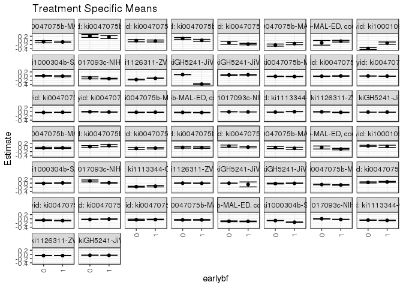

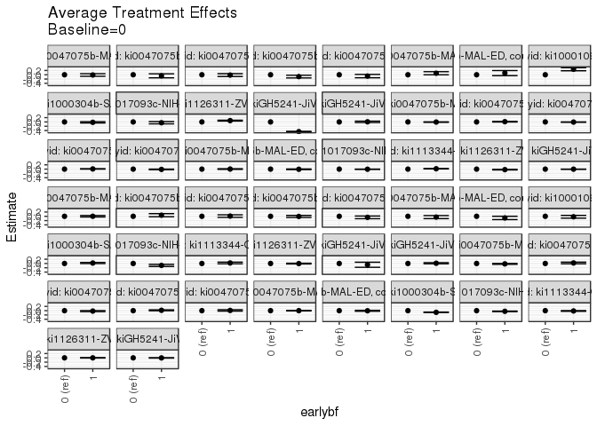

## Results Table

### Parameter: TSM

| agecat | studyid | country | intervention_level | baseline_level | estimate | ci_lower | ci_upper |
| --- | --- | --- | --- | --- | --- | --- | --- |
| 0-3 months | ki0047075b-MAL-ED | BANGLADESH | 0 | NA | -0.0615229 | -0.1131299 | -0.0099160 |
| 0-3 months | ki0047075b-MAL-ED | BANGLADESH | 1 | NA | -0.0724513 | -0.1092566 | -0.0356459 |
| 0-3 months | ki0047075b-MAL-ED | BRAZIL | 0 | NA | 0.2143411 | 0.1461988 | 0.2824834 |
| 0-3 months | ki0047075b-MAL-ED | BRAZIL | 1 | NA | 0.1648517 | 0.0927800 | 0.2369235 |
| 0-3 months | ki0047075b-MAL-ED | INDIA | 0 | NA | -0.0110047 | -0.0657979 | 0.0437885 |
| 0-3 months | ki0047075b-MAL-ED | INDIA | 1 | NA | -0.0262622 | -0.0735673 | 0.0210430 |
| 0-3 months | ki0047075b-MAL-ED | NEPAL | 0 | NA | 0.0902230 | 0.0444786 | 0.1359673 |
| 0-3 months | ki0047075b-MAL-ED | NEPAL | 1 | NA | 0.0047792 | -0.0418776 | 0.0514359 |
| 0-3 months | ki0047075b-MAL-ED | PERU | 0 | NA | -0.1118111 | -0.1822027 | -0.0414195 |
| 0-3 months | ki0047075b-MAL-ED | PERU | 1 | NA | -0.1736304 | -0.2095395 | -0.1377212 |
| 0-3 months | ki0047075b-MAL-ED | SOUTH AFRICA | 0 | NA | -0.2224252 | -0.2730768 | -0.1717735 |
| 0-3 months | ki0047075b-MAL-ED | SOUTH AFRICA | 1 | NA | -0.1521352 | -0.2040056 | -0.1002647 |
| 0-3 months | ki0047075b-MAL-ED | TANZANIA, UNITED REPUBLIC OF | 0 | NA | -0.1133751 | -0.2243435 | -0.0024066 |
| 0-3 months | ki0047075b-MAL-ED | TANZANIA, UNITED REPUBLIC OF | 1 | NA | -0.0352486 | -0.0760868 | 0.0055896 |
| 0-3 months | ki1000109-EE | PAKISTAN | 0 | NA | -0.3849600 | -0.4334750 | -0.3364449 |
| 0-3 months | ki1000109-EE | PAKISTAN | 1 | NA | -0.1271051 | -0.1796444 | -0.0745659 |
| 0-3 months | ki1000304b-SAS-CompFeed | INDIA | 0 | NA | 0.0143928 | -0.0025635 | 0.0313490 |
| 0-3 months | ki1000304b-SAS-CompFeed | INDIA | 1 | NA | -0.0038094 | -0.0314037 | 0.0237849 |
| 0-3 months | ki1017093c-NIH-Crypto | BANGLADESH | 0 | NA | -0.0832654 | -0.1326886 | -0.0338421 |
| 0-3 months | ki1017093c-NIH-Crypto | BANGLADESH | 1 | NA | -0.1201870 | -0.1396272 | -0.1007468 |
| 0-3 months | ki1126311-ZVITAMBO | ZIMBABWE | 0 | NA | -0.1661991 | -0.1811676 | -0.1512306 |
| 0-3 months | ki1126311-ZVITAMBO | ZIMBABWE | 1 | NA | -0.1047658 | -0.1186433 | -0.0908883 |
| 0-3 months | kiGH5241-JiVitA-3 | BANGLADESH | 0 | NA | 0.0711093 | 0.0661474 | 0.0760712 |
| 0-3 months | kiGH5241-JiVitA-3 | BANGLADESH | 1 | NA | -0.3821517 | -0.3952940 | -0.3690094 |
| 0-3 months | kiGH5241-JiVitA-4 | BANGLADESH | 0 | NA | 0.0575249 | 0.0317624 | 0.0832874 |
| 0-3 months | kiGH5241-JiVitA-4 | BANGLADESH | 1 | NA | 0.0635625 | 0.0456933 | 0.0814317 |
| 3-6 months | ki0047075b-MAL-ED | BANGLADESH | 0 | NA | -0.0221183 | -0.0509371 | 0.0067004 |
| 3-6 months | ki0047075b-MAL-ED | BANGLADESH | 1 | NA | -0.0200232 | -0.0474411 | 0.0073946 |
| 3-6 months | ki0047075b-MAL-ED | BRAZIL | 0 | NA | 0.0371295 | -0.0130532 | 0.0873123 |
| 3-6 months | ki0047075b-MAL-ED | BRAZIL | 1 | NA | 0.0882847 | 0.0359392 | 0.1406301 |

[output cut: 70 more lines]

### Parameter: E(Y)

| agecat | studyid | country | intervention_level | baseline_level | estimate | ci_lower | ci_upper |
| --- | --- | --- | --- | --- | --- | --- | --- |
| 0-3 months | ki0047075b-MAL-ED | BANGLADESH | NA | NA | -0.0336824 | -0.0658849 | -0.0014799 |
| 0-3 months | ki0047075b-MAL-ED | BRAZIL | NA | NA | 0.1928587 | 0.1409027 | 0.2448147 |
| 0-3 months | ki0047075b-MAL-ED | INDIA | NA | NA | -0.0204797 | -0.0596747 | 0.0187152 |
| 0-3 months | ki0047075b-MAL-ED | NEPAL | NA | NA | 0.0746202 | 0.0395269 | 0.1097135 |
| 0-3 months | ki0047075b-MAL-ED | PERU | NA | NA | -0.1581085 | -0.1906285 | -0.1255886 |
| 0-3 months | ki0047075b-MAL-ED | SOUTH AFRICA | NA | NA | -0.1020352 | -0.1461845 | -0.0578859 |
| 0-3 months | ki0047075b-MAL-ED | TANZANIA, UNITED REPUBLIC OF | NA | NA | -0.0461667 | -0.0847570 | -0.0075763 |
| 0-3 months | ki1000109-EE | PAKISTAN | NA | NA | -0.3938516 | -0.4364614 | -0.3512419 |
| 0-3 months | ki1000304b-SAS-CompFeed | INDIA | NA | NA | 0.0123467 | -0.0036133 | 0.0283068 |
| 0-3 months | ki1017093c-NIH-Crypto | BANGLADESH | NA | NA | -0.1220821 | -0.1402761 | -0.1038881 |
| 0-3 months | ki1126311-ZVITAMBO | ZIMBABWE | NA | NA | -0.1442586 | -0.1553584 | -0.1331588 |
| 0-3 months | kiGH5241-JiVitA-3 | BANGLADESH | NA | NA | 0.0705261 | 0.0655716 | 0.0754805 |
| 0-3 months | kiGH5241-JiVitA-4 | BANGLADESH | NA | NA | 0.0673143 | 0.0523756 | 0.0822531 |
| 3-6 months | ki0047075b-MAL-ED | BANGLADESH | NA | NA | -0.0218549 | -0.0450356 | 0.0013258 |
| 3-6 months | ki0047075b-MAL-ED | BRAZIL | NA | NA | 0.0604904 | 0.0239698 | 0.0970111 |
| 3-6 months | ki0047075b-MAL-ED | INDIA | NA | NA | -0.0401251 | -0.0685271 | -0.0117231 |
| 3-6 months | ki0047075b-MAL-ED | NEPAL | NA | NA | -0.0214542 | -0.0480456 | 0.0051373 |
| 3-6 months | ki0047075b-MAL-ED | PERU | NA | NA | 0.0273803 | -0.0036374 | 0.0583980 |
| 3-6 months | ki0047075b-MAL-ED | SOUTH AFRICA | NA | NA | -0.0014629 | -0.0396382 | 0.0367125 |
| 3-6 months | ki0047075b-MAL-ED | TANZANIA, UNITED REPUBLIC OF | NA | NA | -0.0705448 | -0.1027245 | -0.0383652 |
| 3-6 months | ki1000109-EE | PAKISTAN | NA | NA | 0.0701161 | 0.0419135 | 0.0983187 |
| 3-6 months | ki1000304b-SAS-CompFeed | INDIA | NA | NA | -0.0166348 | -0.0360336 | 0.0027639 |
| 3-6 months | ki1017093c-NIH-Crypto | BANGLADESH | NA | NA | 0.0267740 | 0.0099602 | 0.0435879 |
| 3-6 months | ki1113344-GMS-Nepal | NEPAL | NA | NA | -0.1643126 | -0.1830906 | -0.1455346 |
| 3-6 months | ki1126311-ZVITAMBO | ZIMBABWE | NA | NA | 0.0013347 | -0.0085345 | 0.0112039 |
| 3-6 months | kiGH5241-JiVitA-3 | BANGLADESH | NA | NA | -0.0034526 | -0.0083193 | 0.0014141 |
| 3-6 months | kiGH5241-JiVitA-4 | BANGLADESH | NA | NA | -0.0090589 | -0.0227889 | 0.0046710 |
| 6-12 months | ki0047075b-MAL-ED | BANGLADESH | NA | NA | -0.0803907 | -0.0907811 | -0.0700002 |
| 6-12 months | ki0047075b-MAL-ED | BRAZIL | NA | NA | 0.0065644 | -0.0129183 | 0.0260472 |
| 6-12 months | ki0047075b-MAL-ED | INDIA | NA | NA | -0.0776724 | -0.0898619 | -0.0654829 |
| 6-12 months | ki0047075b-MAL-ED | NEPAL | NA | NA | -0.0488126 | -0.0594641 | -0.0381610 |
| 6-12 months | ki0047075b-MAL-ED | PERU | NA | NA | -0.0373127 | -0.0513600 | -0.0232653 |
| 6-12 months | ki0047075b-MAL-ED | SOUTH AFRICA | NA | NA | -0.0546093 | -0.0721102 | -0.0371085 |
| 6-12 months | ki0047075b-MAL-ED | TANZANIA, UNITED REPUBLIC OF | NA | NA | -0.1240143 | -0.1396706 | -0.1083579 |
| 6-12 months | ki1000304b-SAS-CompFeed | INDIA | NA | NA | -0.0862318 | -0.0909003 | -0.0815633 |
| 6-12 months | ki1017093c-NIH-Crypto | BANGLADESH | NA | NA | -0.0315658 | -0.0388594 | -0.0242722 |
| 6-12 months | ki1113344-GMS-Nepal | NEPAL | NA | NA | -0.0629524 | -0.0714846 | -0.0544202 |
| 6-12 months | ki1126311-ZVITAMBO | ZIMBABWE | NA | NA | -0.0501592 | -0.0551386 | -0.0451799 |
| 6-12 months | kiGH5241-JiVitA-4 | BANGLADESH | NA | NA | -0.0383413 | -0.0427080 | -0.0339747 |
| 12-24 months | ki0047075b-MAL-ED | BANGLADESH | NA | NA | -0.0175081 | -0.0228924 | -0.0121238 |
| 12-24 months | ki0047075b-MAL-ED | BRAZIL | NA | NA | -0.0013016 | -0.0119070 | 0.0093038 |
| 12-24 months | ki0047075b-MAL-ED | INDIA | NA | NA | -0.0098833 | -0.0150187 | -0.0047479 |
| 12-24 months | ki0047075b-MAL-ED | NEPAL | NA | NA | -0.0295113 | -0.0345712 | -0.0244514 |
| 12-24 months | ki0047075b-MAL-ED | PERU | NA | NA | -0.0092560 | -0.0162726 | -0.0022393 |
| 12-24 months | ki0047075b-MAL-ED | SOUTH AFRICA | NA | NA | -0.0148687 | -0.0225262 | -0.0072113 |
| 12-24 months | ki0047075b-MAL-ED | TANZANIA, UNITED REPUBLIC OF | NA | NA | -0.0393265 | -0.0471437 | -0.0315094 |
| 12-24 months | ki1017093c-NIH-Crypto | BANGLADESH | NA | NA | -0.0057326 | -0.0097260 | -0.0017391 |
| 12-24 months | ki1113344-GMS-Nepal | NEPAL | NA | NA | -0.0149004 | -0.0201971 | -0.0096037 |
| 12-24 months | ki1126311-ZVITAMBO | ZIMBABWE | NA | NA | -0.0527908 | -0.0626365 | -0.0429450 |
| 12-24 months | kiGH5241-JiVitA-4 | BANGLADESH | NA | NA | -0.0145970 | -0.0164717 | -0.0127223 |

### Parameter: ATE

| agecat | studyid | country | intervention_level | baseline_level | estimate | ci_lower | ci_upper |
| --- | --- | --- | --- | --- | --- | --- | --- |
| 0-3 months | ki0047075b-MAL-ED | BANGLADESH | 0 | 0 | 0.0000000 | 0.0000000 | 0.0000000 |
| 0-3 months | ki0047075b-MAL-ED | BANGLADESH | 1 | 0 | -0.0109283 | -0.0714854 | 0.0496288 |
| 0-3 months | ki0047075b-MAL-ED | BRAZIL | 0 | 0 | 0.0000000 | 0.0000000 | 0.0000000 |
| 0-3 months | ki0047075b-MAL-ED | BRAZIL | 1 | 0 | -0.0494894 | -0.1438634 | 0.0448847 |
| 0-3 months | ki0047075b-MAL-ED | INDIA | 0 | 0 | 0.0000000 | 0.0000000 | 0.0000000 |
| 0-3 months | ki0047075b-MAL-ED | INDIA | 1 | 0 | -0.0152574 | -0.0811603 | 0.0506454 |
| 0-3 months | ki0047075b-MAL-ED | NEPAL | 0 | 0 | 0.0000000 | 0.0000000 | 0.0000000 |
| 0-3 months | ki0047075b-MAL-ED | NEPAL | 1 | 0 | -0.0854438 | -0.1483856 | -0.0225020 |
| 0-3 months | ki0047075b-MAL-ED | PERU | 0 | 0 | 0.0000000 | 0.0000000 | 0.0000000 |
| 0-3 months | ki0047075b-MAL-ED | PERU | 1 | 0 | -0.0618193 | -0.1404778 | 0.0168392 |
| 0-3 months | ki0047075b-MAL-ED | SOUTH AFRICA | 0 | 0 | 0.0000000 | 0.0000000 | 0.0000000 |
| 0-3 months | ki0047075b-MAL-ED | SOUTH AFRICA | 1 | 0 | 0.0702900 | -0.0032917 | 0.1438718 |
| 0-3 months | ki0047075b-MAL-ED | TANZANIA, UNITED REPUBLIC OF | 0 | 0 | 0.0000000 | 0.0000000 | 0.0000000 |
| 0-3 months | ki0047075b-MAL-ED | TANZANIA, UNITED REPUBLIC OF | 1 | 0 | 0.0781264 | -0.0400392 | 0.1962921 |
| 0-3 months | ki1000109-EE | PAKISTAN | 0 | 0 | 0.0000000 | 0.0000000 | 0.0000000 |
| 0-3 months | ki1000109-EE | PAKISTAN | 1 | 0 | 0.2578548 | 0.1862723 | 0.3294374 |
| 0-3 months | ki1000304b-SAS-CompFeed | INDIA | 0 | 0 | 0.0000000 | 0.0000000 | 0.0000000 |
| 0-3 months | ki1000304b-SAS-CompFeed | INDIA | 1 | 0 | -0.0182021 | -0.0483366 | 0.0119323 |
| 0-3 months | ki1017093c-NIH-Crypto | BANGLADESH | 0 | 0 | 0.0000000 | 0.0000000 | 0.0000000 |
| 0-3 months | ki1017093c-NIH-Crypto | BANGLADESH | 1 | 0 | -0.0369216 | -0.0900218 | 0.0161786 |
| 0-3 months | ki1126311-ZVITAMBO | ZIMBABWE | 0 | 0 | 0.0000000 | 0.0000000 | 0.0000000 |
| 0-3 months | ki1126311-ZVITAMBO | ZIMBABWE | 1 | 0 | 0.0614333 | 0.0415558 | 0.0813108 |
| 0-3 months | kiGH5241-JiVitA-3 | BANGLADESH | 0 | 0 | 0.0000000 | 0.0000000 | 0.0000000 |
| 0-3 months | kiGH5241-JiVitA-3 | BANGLADESH | 1 | 0 | -0.4532610 | -0.4671511 | -0.4393708 |
| 0-3 months | kiGH5241-JiVitA-4 | BANGLADESH | 0 | 0 | 0.0000000 | 0.0000000 | 0.0000000 |
| 0-3 months | kiGH5241-JiVitA-4 | BANGLADESH | 1 | 0 | 0.0060376 | -0.0254755 | 0.0375507 |
| 3-6 months | ki0047075b-MAL-ED | BANGLADESH | 0 | 0 | 0.0000000 | 0.0000000 | 0.0000000 |
| 3-6 months | ki0047075b-MAL-ED | BANGLADESH | 1 | 0 | 0.0020951 | -0.0309772 | 0.0351674 |
| 3-6 months | ki0047075b-MAL-ED | BRAZIL | 0 | 0 | 0.0000000 | 0.0000000 | 0.0000000 |
| 3-6 months | ki0047075b-MAL-ED | BRAZIL | 1 | 0 | 0.0511551 | -0.0211729 | 0.1234831 |

[output cut: 70 more lines]